# Turbine Collision Risk: Generate Distribution Data

Cédric Scherer https://cedricscherer.com (Leibniz Institute for Zoo and Wildlife Research)https://www.izw-berlin.de/en/home.html , Christian Voigt (Leibniz Institute for Zoo and Wildlife Research)https://www.izw-berlin.de/en/home.html  
2022-09-01

## Preparation

```r
library(tidyverse)
library(here)
library(broom)

## source functions to generate and visualize distributions
source(here("R", "src", "generate-distributions.R"))
```

## Research Question

- Predictive power of the acoustic monitoring

> Is the predictive power of the current acoustic monitoring sufficient enough to estimate the true number of killed bats?

### Predictions

The predictive power of the acoustic monitoring for the extrapolation of the expected number of stroke victims is decreasing

- in case the crossing bats are not distributed uniformly or randomly.
- with increasing length of the rotor blades.
- for species with high-frequency echo calls.

### Open Questions

- wie die Dichte skalieren zwischen großen und kleinen Windrädern?
  - z.B. von innen nach außen abhängig von relativer oder absoluter Distanz zum Mittelpunkt?
- globale oder lokale Anzahl an Fledermäusen konstant halten?

We have the following parameters we can vary:

- length of rotor blades (`radius_rotor`) - 60 m versus 33 m
  - determines area of wind turbine (`area_rotor` as `pi * radius_rotor^2`)
- proportion of area covered by acoustic monitoring (`proportion_covered`)
  - determines area of acoustic monitoring (`area_monitored` as `area_rotor * proportion_covered`)
  - determines radius to detect bars (`radius_monitored` as `sqrt(area_monitored / pi)`)
- number of bats simulated (`n`)
  - could be either total (for now) or number monitored (maybe later)

## Simulations Distributions

```r
rds <- here("output", "data-proc", "simulation-runs-norm.rds")
if (!file.exists(rds)) {
  scenarios <- simulate_multiple_distributions(
    runs = 200,   ## repetitions per combination, also used for seeding
    prop_monitored = c(.04, seq(.05, .5, by = .05), .23),
    #n = c(100L, 250L, 500L, 1000L, 5000L, 15000L),
    n = c(100L, 200L, 400L, 800L, 1600L, 3200L),
    skewness = c(1, 3, 5)
  )
  write_rds(scenarios, rds)
} else {
  scenarios <- read_rds(rds)
}

scenarios <-
  scenarios %>%
   mutate(distribution = factor(
     distribution,
     levels = c("uniform", "random",
                "inner_1", "inner_3",
                "outer_1", "outer_3",
                "bottom_1", "bottom_3",
                "top_1", "top_3")
    )
  )
```

## Analysis

### Fitting per Distribution x Prop Monitored

```r
lm_scenarios <-
  scenarios %>%
  ## remove extremely skewed distributions
  filter(!str_detect(distribution, "_5$")) %>%
  ## add id
  #arrange(n, prop_monitored, distribution) %>%
  #group_by(distribution, prop_monitored, n) %>%
  #mutate(id = cur_group_id(), passes = n) %>%
  #filter(id %in% 1:3) %>%
  #nest(data = -c(id, distribution, prop_monitored, passes)) %>%
  nest(data = -c(distribution, prop_monitored)) %>%
  mutate(
    fit = map(data, ~ lm(n_fatalities ~ n_monitored, data = .x)),
    tidied = map(fit, tidy),
    glance = map(fit, broom::glance),
    augment = map(fit, broom::augment),
    rsq = glance %>% map_dbl('r.squared'),
    slope = tidied %>% map_dbl(function(x) x$estimate[2])
  ) #%>%
  #unnest(tidied)

fits_scenarios <-
  lm_scenarios %>%
  #dplyr::select(distribution, passes, prop_monitored, rsq, slope)
  dplyr::select(distribution, prop_monitored, rsq, slope) %>%
  group_by(prop_monitored) %>%
  mutate(
    slope_diff = slope - slope[which(distribution == "uniform")],
    rsq_diff = rsq - rsq[which(distribution == "uniform")]
  )
```

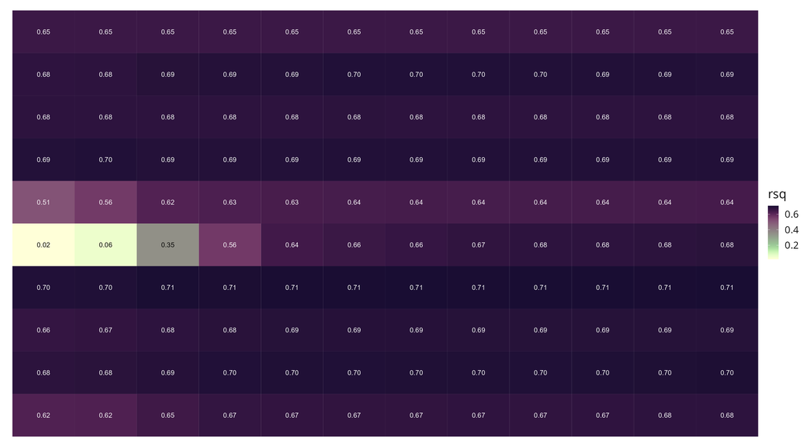

```r
## R-squared -------------------------------------------------------------------
ggplot(fits_scenarios, aes(factor(prop_monitored), fct_rev(distribution), fill = rsq)) +
  geom_tile() +
  geom_text(aes(label = sprintf("%1.2f", rsq), color = rsq < .5)) +
  scico::scale_fill_scico(palette = "tokyo", direction = -1) +
  scale_color_manual(values = c("white", "black"), guide = "none")
```

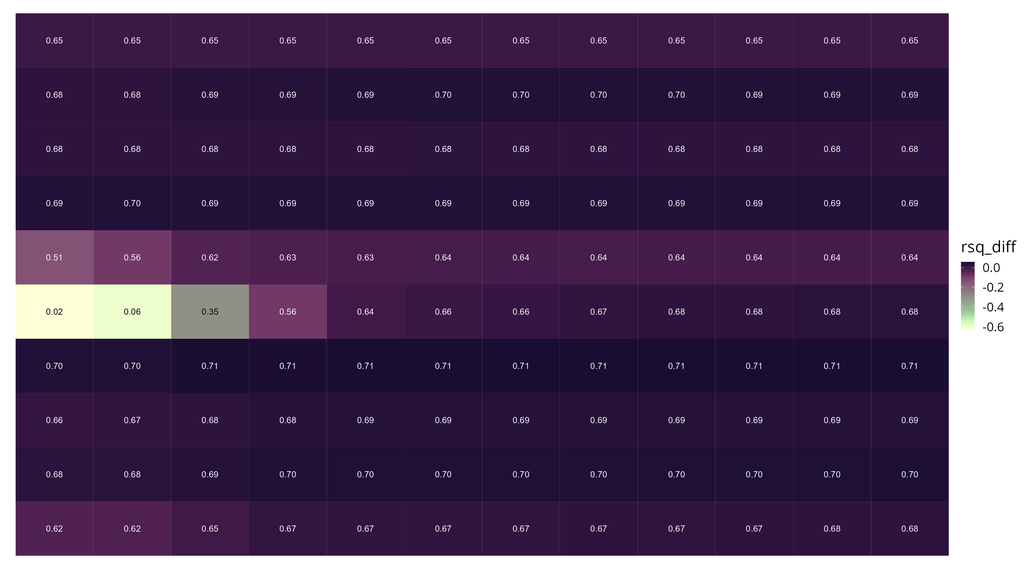

```r
## differences
ggplot(fits_scenarios, aes(factor(prop_monitored), fct_rev(distribution), fill = rsq_diff)) +
  geom_tile() +
  geom_text(aes(label = sprintf("%1.2f", rsq), color = rsq < .5)) +
  scico::scale_fill_scico(palette = "tokyo", direction = -1) +
  scale_color_manual(values = c("white", "black"), guide = "none")
```

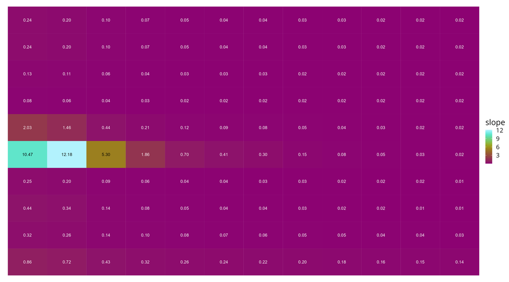

```r
## Slope -----------------------------------------------------------------------
ggplot(fits_scenarios, aes(factor(prop_monitored), fct_rev(distribution), fill = slope)) +
  geom_tile() +
  geom_text(aes(label = sprintf("%2.2f", slope), color = slope > 5)) +
  scico::scale_fill_scico(palette = "hawaii") +
  scale_color_manual(values = c("white", "black"), guide = "none")
```

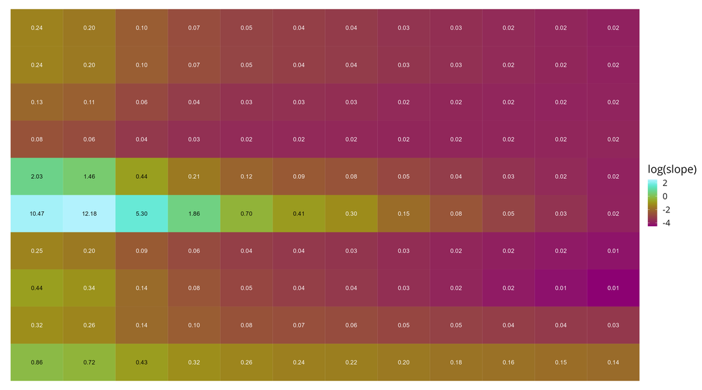

```r
## log-scale
ggplot(fits_scenarios, aes(factor(prop_monitored), fct_rev(distribution), fill = log(slope))) +
  geom_tile() +
  geom_text(aes(label = sprintf("%2.2f", slope), color = log(slope) > -1)) +
  scico::scale_fill_scico(palette = "hawaii") +
  scale_color_manual(values = c("white", "black"), guide = "none")
```

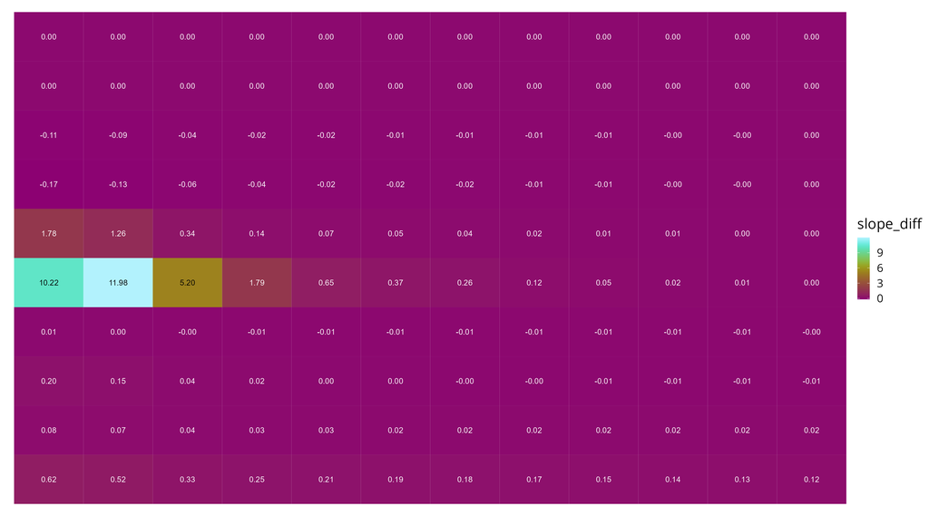

```r
## differences
ggplot(fits_scenarios, aes(factor(prop_monitored), fct_rev(distribution), fill = slope_diff)) +
  geom_tile() +
  geom_text(aes(label = sprintf("%2.2f", slope_diff), color = slope_diff > 5)) +
  scico::scale_fill_scico(palette = "hawaii") +
  scale_color_manual(values = c("white", "black"), guide = "none")
```

### Fitting per Distribution x Prop Monitored x Bat Passes

```r
lm_scenarios_n <-
  scenarios %>%
  ## remove extremely skewed distributions
  filter(!str_detect(distribution, "_5$")) %>%
  nest(data = -c(distribution, prop_monitored, n)) %>%
  mutate(
    fit = map(data, ~ lm(n_fatalities ~ n_monitored, data = .x)),
    tidied = map(fit, tidy),
    glance = map(fit, broom::glance),
    augment = map(fit, broom::augment),
    rsq = glance %>% map_dbl('r.squared'),
    slope = tidied %>% map_dbl(function(x) x$estimate[2])
  )

fits_scenarios_n <-
  lm_scenarios_n %>%
  dplyr::select(distribution, prop_monitored, n, rsq, slope) %>%
  group_by(prop_monitored, n) %>%
  mutate(
    slope_diff = slope - slope[which(distribution == "uniform")],
    rsq_diff = rsq - rsq[which(distribution == "uniform")]
  )
```

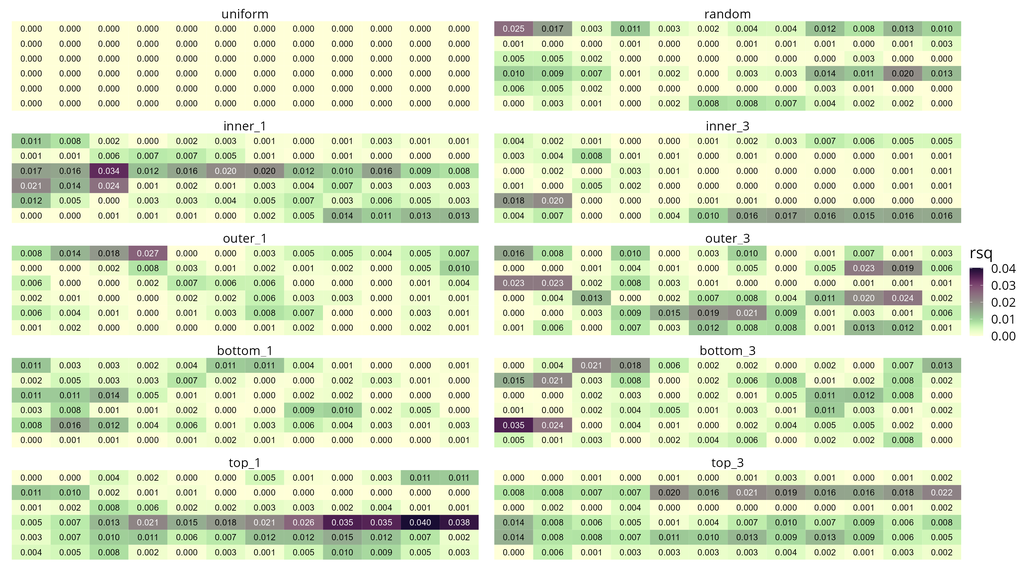

```r
## R-squared -------------------------------------------------------------------
ggplot(fits_scenarios_n, aes(factor(prop_monitored), fct_rev(factor(n)), fill = rsq)) +
  geom_tile() +
  geom_text(aes(label = sprintf("%1.3f", round(rsq, 3)), color = rsq < .02)) +
  facet_wrap(~distribution, ncol = 2) +
  scico::scale_fill_scico(palette = "tokyo", direction = -1) +
  scale_color_manual(values = c("white", "black"), guide = "none")
```

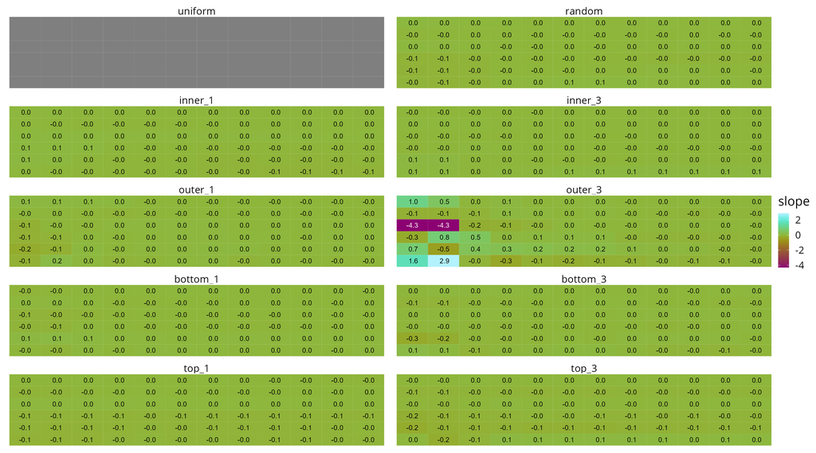

```r
## Slope -----------------------------------------------------------------------
ggplot(fits_scenarios_n, aes(factor(prop_monitored), fct_rev(factor(n)), fill = slope)) +
  geom_tile() +
  geom_text(aes(label = sprintf("%4.1f", slope), color = slope > -1)) +
  facet_wrap(~distribution, ncol = 2) +
  scico::scale_fill_scico(palette = "hawaii") +
  scale_color_manual(values = c("white", "black"), guide = "none")
```

**Session Info**

```r
Sys.time()
```

```
[1] "2022-09-01 19:09:51 CEST"
```